# Examining the Impact of Environmental Exposures on Body Mass Index (BMI)

Mona Bandov

Published: 08 August 2024

```r
#HELIX.RData Download:
helix_file_path <- "~/Library/CloudStorage/GoogleDrive-bandov@usc.edu/.shortcut-targets-by-id/1oBvDKkpKxGnEoNogWDoXV--27W2spqKh/HELIX_data/HELIX.RData"
load(helix_file_path)
```

```r
# Metabol_serum.RData Download:
metabol_serum_file_path <- "~/Library/CloudStorage/GoogleDrive-bandov@usc.edu/.shortcut-targets-by-id/1oBvDKkpKxGnEoNogWDoXV--27W2spqKh/HELIX_data/metabol_serum.RData"
load(metabol_serum_file_path)
```

```r
#Adjusting BMI Category
#Binning BMI so that predictive power increases
phenotype <- phenotype %>%
  mutate(hs_bmi_c_cat = ifelse(hs_bmi_c_cat %in% c(1, 2), 0,
                               ifelse(hs_bmi_c_cat %in% c(3, 4), 1, hs_bmi_c_cat)))
```

```r
#write.csv(full_data_with_meta_imputed_factored, "full_data_with_imputed_factored.csv", row.names = FALSE)
```

```r
full_data_with_meta_imputed <- read_csv("full_data_with_meta_imputed.csv")
full_data_with_meta_imputed_factored<- read_csv("full_data_with_imputed_factored.csv")
```

# Abstract

The LASSO performed better for the model with metabolomic data, followed by GBM and then random forest due to the nature of the data set.

# Hypothesis

# Introduction

[figure not shown]

HELIX: Building the Early-Life Exposome

Recent studies emphasize the important role of maternal diet during pregnancy, demonstrating that balanced maternal nutrition can mitigate the adverse effects of environmental exposures like phthalates on child BMI, suggesting that improved dietary practices during pregnancy can lead to better health outcomes for children ([NCBI, 2024](https://www.ncbi.nlm.nih.gov/pmc/articles/PMC9824240/)).

Phthalate exposure has been linked to various health issues, including obesity, type II diabetes, thyroid dysfunction, higher blood pressure, precocious puberty, and reproductive effects. It also impacts the respiratory system (allergy, asthma) and nervous system (delayed neurodevelopment, social impairment) ([Serrano et al., 2021](https://www.ncbi.nlm.nih.gov/pmc/articles/PMC7483495/)).

# Methods

## Data Preparation

### Imputation

Missing values were imputed with the mean for relevant columns. Rows were not removed to retain sample size.

### Data Splitting

A hold out set was implemented to train and test the data.

## Variables

### Outcome Variable

- Body Mass Index (BMI) categorized (`hs_bmi_c_cat`)
  - 0: Underweight and Normal Weight
  - 1: Overweight and Obese

### Covariates

- `h_cohort`
- `e3_sex_None`
- `hs_child_age_None`

### Diet Variables (12 Diet)

- `e3_alcpreg_yn_None`
- `h_cereal_preg_Ter`
- `h_dairy_preg_Ter`
- `h_fastfood_preg_Ter`
- `h_folic_t1_None`
- `h_fruit_preg_Ter`
- `h_meat_preg_Ter`
- `h_pamod_t3_None`
- `h_fish_preg_Ter`
- `h_legume_preg_Ter`
- `h_pavig_t3_None`
- `h_veg_preg_Ter`

### Chemical Variables (10 Chemicals)

- `hs_mbzp_madj_Log2`
- `hs_mecpp_madj_Log2`
- `hs_mep_madj_Log2`
- `hs_mibp_madj_Log2`
- `hs_mnbp_madj_Log2`
- `hs_oxominp_madj_Log2`
- `hs_mehhp_madj_Log2`
- `hs_meohp_madj_Log2`
- `hs_ohminp_madj_Log2`
- `hs_mehp_madj_Log2`

## Statistical Analysis and Models

### Primary Models

Model 1 (A-D) were constructed using Lasso regression techniques to see the effect of added predictors: - **Lasso Regression**: Used to identify the most relevant predictors by applying L1 regularization.

### Model 1A: Outcome ~ Covariates

Examines the effect of covariates on BMI.

### Model 1B: Outcome ~ Covariates + Diet

Examines the effect of covariates and diet on BMI.

### Model 1C: Outcome ~ Covariates + Diet + Chemicals

Examines the effect of covariates, diet, and chemical exposures on BMI.

### Model 1D: Outcome ~ Covariates + Diet + Chemicals + Meta

Examines the effect of covariates, diet, chemical exposures, and metabolomic data on BMI.

### Secondary Model (Used on the best model from Model 1)

- **Lasso Regression**: Used to identify the most relevant predictors by applying L1 regularization.
- **Random Forest**: Used to determine the best machine learning algorithm on the best performing dataset.
- **Gradient Boosting Machine (GBM)**: Used to determine the bet machine learning algorithm on the best performing dataset.

### Model 2A: LASSO on best performing model in Model 1

Applied LASSO to the best performing dataset with metabolmics data.

### Model 2B Random Forest best performing model in Model 1

Applied Random Forest (RF) to the best performing data set in Model 1.

### Model 2C: Gradient Boosting Machine (GBM) on best performing model in Model 1

Applied to Gradient Boosting Machine (GBM) to the best performing data set in Model 1.

## Model Evaluation

### Performance Metrics

- **Area Under the Curve (AUC)**: ROC curve was used to assess the model’s predictive accuracy.
- **ROC Curve Comparison**: ROC curves were plotted for both models to compare their performance visually.
- **Accuracy**: The proportion of true results (both true positives and true negatives) among the total number of cases examined.

# Data

The complexity of exposure to environmental contaminants has increased because evolving environmental and lifestyle factors. The exposome includes all environmental (non-genetic) exposures an individual encounters from conception through old age. The HELIX (Human Early-Life Exposome) project focuses on the early-life exposome, which integrates all environmental hazards that mothers and children are exposed to and linking these exposures to health, growth, and development risks.

Pregnancy and early childhood are critical times when children are more vulnerable to environmental damage, which can have lifelong effects. Understanding the exposome during these periods can help prevent diseases, since early interventions can change biological foundation and promote healthy development. HELIX cna help show how different environmental exposures together affect health outcomes and risks.

There are six existing European birth cohort studies: Born in Bradford (BiB), Etude des Déterminants pré et postnatals du développement et de la santé de l’Enfant (EDEN), INfancia y Medio Ambiente (INMA), Kaunas Cohort (KANC), Norwegian Mother, Father and Child Cohort Study (MoBa), and Rhea Mother-Child Cohort Study. These cohorts have collected extensive data from national and EU-funded projects. HELIX supplements this data with advanced tools and methods to measure and integrate the chemical, physical, and molecular environment, linking these measurements to child health outcomes.

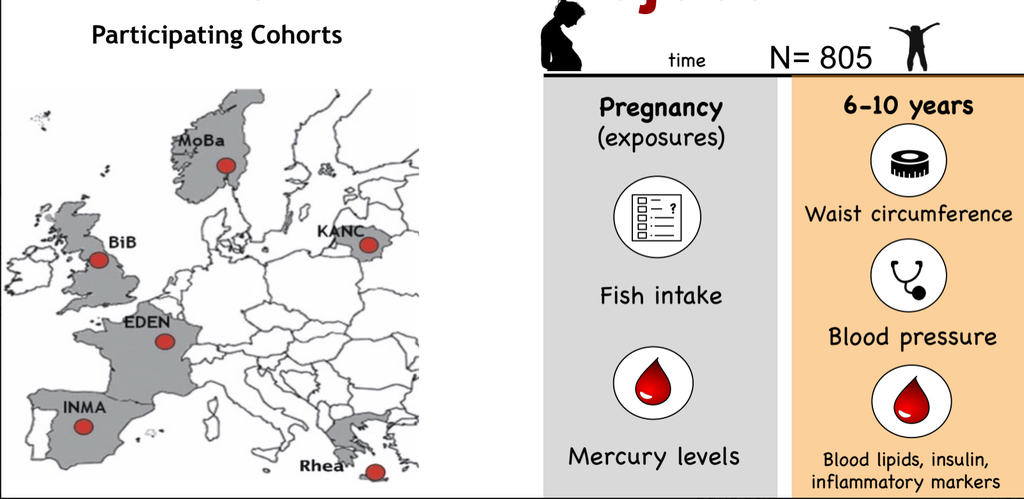

Smartphones are utilized to measure air pollution, UV radiation, physical activity, and noise exposure. Advanced laboratory techniques identify biological markers of various chemical exposures, such as contaminants in food, consumer products, and water. HELIX has gathered extensive exposome data from mothers and children, making it the largest study on this topic. The study design is multilevel: the first level includes 31,472 mother-child pairs recruited during pregnancy across the six cohorts; the second level consists of a subcohort of 1301 mother-child pairs with detailed measurements of biomarkers, omics signatures, and health outcomes at ages 6-11 years; and the third level involves repeat-sampling panel studies with about 150 children and 150 pregnant women to collect personal exposure data.

For more details on the study design see Vrijheid, Slama, et al. EHP 2014. see https://www.projecthelix.eu/index.php/es/data-inventory for more information regarding the study.

# Codebook

```r
codebook_file_path <- "~/Library/CloudStorage/GoogleDrive-bandov@usc.edu/.shortcut-targets-by-id/1oBvDKkpKxGnEoNogWDoXV--27W2spqKh/HELIX_data/HELIX.RData"
load(codebook_file_path)
#  Chemicals
filtered_codebook_chemicals <- codebook %>%
  filter(domain == "Chemicals" &
         family == "Phthalates" &
         period == "Pregnancy" &
         variable_name != "hs_sumDEHP_madj_Log2")

# Covariates
filtered_codebook_covariates <- codebook %>%
  filter(domain == "Covariates" &
         variable_name %in% c("e3_sex_None", "h_cohort", "hs_child_age_None"))

# Phenotype
filtered_codebook_phenotype <- codebook %>%
  filter(domain == "Phenotype" &
         variable_name %in% c("hs_bmi_c_cat"))

# Lifestyle
filtered_codebook_lifestyles <- codebook %>%
  filter(domain == "Lifestyles" & period == "Pregnancy" & subfamily == "Diet")

# Combining all the information
combined_codebook <- bind_rows(
  filtered_codebook_chemicals,
  filtered_codebook_covariates,
  filtered_codebook_phenotype,
  filtered_codebook_lifestyles
)
```

## Data Summary Exposures: Lifestyles (Diet)

```r
#Lifestyle
filtered_codebook_lifestyles <- codebook %>%
  filter(domain == "Lifestyles" & period == "Pregnancy")
selectExposures <- filtered_codebook_lifestyles$variable_name
summarytools::view(dfSummary(exposome[,names(exposome) %in% selectExposures],
                             style = 'grid',
                             plain.ascii = FALSE,
                             valid.col = FALSE,
                             headings = FALSE),
                   method = "render")
```

| **No** | **Variable** | **Stats / Values** | **Freqs (% of Valid)** | **Graph** | **Missing** |
| --- | --- | --- | --- | --- | --- |
| 1 | e3_alcpreg_yn_None [factor] | 1. 0 2. 1 | 896 ( 68.9% ) 405 ( 31.1% ) |  | 0 (0.0%) |
| 2 | h_cereal_preg_Ter [factor] | 1. (0,9] 2. (9,27.3] 3. (27.3,Inf] | 531 ( 40.8% ) 459 ( 35.3% ) 311 ( 23.9% ) |  | 0 (0.0%) |
| 3 | h_dairy_preg_Ter [factor] | 1. (0,17.1] 2. (17.1,27.1] 3. (27.1,Inf] | 270 ( 20.8% ) 380 ( 29.2% ) 651 ( 50.0% ) |  | 0 (0.0%) |
| 4 | h_fastfood_preg_Ter [factor] | 1. (0,0.25] 2. (0.25,0.83] 3. (0.83,Inf] | 94 ( 7.2% ) 535 ( 41.1% ) 672 ( 51.7% ) |  | 0 (0.0%) |
| 5 | h_fish_preg_Ter [factor] | 1. (0,1.9] 2. (1.9,4.1] 3. (4.1,Inf] | 343 ( 26.4% ) 490 ( 37.7% ) 468 ( 36.0% ) |  | 0 (0.0%) |
| 6 | h_folic_t1_None [factor] | 1. 0 2. 1 | 606 ( 46.6% ) 695 ( 53.4% ) |  | 0 (0.0%) |
| 7 | h_fruit_preg_Ter [factor] | 1. (0,0.6] 2. (0.6,18.2] 3. (18.2,Inf] | 6 ( 0.5% ) 922 ( 70.9% ) 373 ( 28.7% ) |  | 0 (0.0%) |
| 8 | h_legume_preg_Ter [factor] | 1. (0,0.5] 2. (0.5,2] 3. (2,Inf] | 245 ( 18.8% ) 269 ( 20.7% ) 787 ( 60.5% ) |  | 0 (0.0%) |
| 9 | h_meat_preg_Ter [factor] | 1. (0,6.5] 2. (6.5,10] 3. (10,Inf] | 427 ( 32.8% ) 387 ( 29.7% ) 487 ( 37.4% ) |  | 0 (0.0%) |
| 10 | h_pamod_t3_None [factor] | 1. None 2. Often 3. Sometimes 4. Very Often | 42 ( 3.2% ) 474 ( 36.4% ) 191 ( 14.7% ) 594 ( 45.7% ) |  | 0 (0.0%) |
| 11 | h_pavig_t3_None [factor] | 1. High 2. Low 3. Medium | 47 ( 3.6% ) 952 ( 73.2% ) 302 ( 23.2% ) |  | 0 (0.0%) |
| 12 | h_veg_preg_Ter [factor] | 1. (0,8.8] 2. (8.8,16.5] 3. (16.5,Inf] | 539 ( 41.4% ) 470 ( 36.1% ) 292 ( 22.4% ) |  | 0 (0.0%) |

Generated by summarytools 1.0.1 ([R](https://www.r-project.org/) version 4.4.1)  
2024-08-08

## Data Summary Exposures: Chemicals (Phthalates)

```r
#Chemical
filtered_codebook_chemicals <- codebook %>%
  filter(domain == "Chemicals" &
         family == "Phthalates" &
         period == "Pregnancy" &
         variable_name != "hs_sumDEHP_madj_Log2")
selectExposures <- filtered_codebook_chemicals$variable_name
summarytools::view(dfSummary(exposome[,names(exposome) %in% selectExposures],
                             style = 'grid',
                             plain.ascii = FALSE,
                             valid.col = FALSE,
                             headings = FALSE),
                   method = "render")
```

| **No** | **Variable** | **Stats / Values** | **Freqs (% of Valid)** | **Graph** | **Missing** |
| --- | --- | --- | --- | --- | --- |
| 1 | hs_mbzp_madj_Log2 [numeric] | Mean (sd) : 3 (1.6) min ≤ med ≤ max: -3.7 ≤ 2.9 ≤ 9.3 IQR (CV) : 2.2 (0.5) | 873 distinct values |  | 0 (0.0%) |
| 2 | hs_mecpp_madj_Log2 [numeric] | Mean (sd) : 5 (1) min ≤ med ≤ max: 2.4 ≤ 4.9 ≤ 10.4 IQR (CV) : 1.3 (0.2) | 734 distinct values |  | 0 (0.0%) |
| 3 | hs_mehhp_madj_Log2 [numeric] | Mean (sd) : 4.2 (1.2) min ≤ med ≤ max: -0.5 ≤ 4.1 ≤ 9.9 IQR (CV) : 1.3 (0.3) | 890 distinct values |  | 0 (0.0%) |
| 4 | hs_mehp_madj_Log2 [numeric] | Mean (sd) : 2.9 (1.4) min ≤ med ≤ max: -7.5 ≤ 3.1 ≤ 8.7 IQR (CV) : 2 (0.5) | 873 distinct values |  | 0 (0.0%) |
| 5 | hs_meohp_madj_Log2 [numeric] | Mean (sd) : 3.8 (1.2) min ≤ med ≤ max: 0 ≤ 3.7 ≤ 9.6 IQR (CV) : 1.3 (0.3) | 894 distinct values |  | 0 (0.0%) |
| 6 | hs_mep_madj_Log2 [numeric] | Mean (sd) : 7.8 (1.8) min ≤ med ≤ max: 3.3 ≤ 7.8 ≤ 14.1 IQR (CV) : 2.5 (0.2) | 874 distinct values |  | 0 (0.0%) |
| 7 | hs_mibp_madj_Log2 [numeric] | Mean (sd) : 5.3 (1.1) min ≤ med ≤ max: 0.9 ≤ 5.3 ≤ 9.5 IQR (CV) : 1.3 (0.2) | 871 distinct values |  | 0 (0.0%) |
| 8 | hs_mnbp_madj_Log2 [numeric] | Mean (sd) : 5 (1.2) min ≤ med ≤ max: -0.7 ≤ 4.9 ≤ 12.7 IQR (CV) : 1.4 (0.2) | 897 distinct values |  | 0 (0.0%) |
| 9 | hs_ohminp_madj_Log2 [numeric] | Mean (sd) : -0.3 (1.5) min ≤ med ≤ max: -11.5 ≤ -0.2 ≤ 6.1 IQR (CV) : 1 (-5.1) | 730 distinct values |  | 0 (0.0%) |
| 10 | hs_oxominp_madj_Log2 [numeric] | Mean (sd) : -0.1 (1.6) min ≤ med ≤ max: -11.6 ≤ 0 ≤ 5.6 IQR (CV) : 1.2 (-28.7) | 766 distinct values |  | 0 (0.0%) |

Generated by summarytools 1.0.1 ([R](https://www.r-project.org/) version 4.4.1)  
2024-08-08

## Data Summary Exposures: Covariate

```r
# Covariates
filtered_codebook_covariates <- codebook %>%
  filter(variable_name %in% c("e3_sex_None", "h_cohort", "hs_child_age_None"))
selectCovariates <- filtered_codebook_covariates$variable_name
summarytools::view(dfSummary(covariates[,names(covariates) %in% selectCovariates],
                             style = 'grid',
                             plain.ascii = FALSE,
                             valid.col = FALSE,
                             headings = FALSE),
                   method = "render")
```

| **No** | **Variable** | **Stats / Values** | **Freqs (% of Valid)** | **Graph** | **Missing** |
| --- | --- | --- | --- | --- | --- |
| 1 | h_cohort [factor] | 1. 1 2. 2 3. 3 4. 4 5. 5 6. 6 | 202 ( 15.5% ) 198 ( 15.2% ) 224 ( 17.2% ) 207 ( 15.9% ) 272 ( 20.9% ) 198 ( 15.2% ) |  | 0 (0.0%) |
| 2 | e3_sex_None [factor] | 1. female 2. male | 608 ( 46.7% ) 693 ( 53.3% ) |  | 0 (0.0%) |
| 3 | hs_child_age_None [numeric] | Mean (sd) : 8 (1.6) min ≤ med ≤ max: 5.4 ≤ 8 ≤ 12.1 IQR (CV) : 2.4 (0.2) | 879 distinct values |  | 0 (0.0%) |

Generated by summarytools 1.0.1 ([R](https://www.r-project.org/) version 4.4.1)  
2024-08-08

# Data Exploration

```r
# Combining covariates with phenotype (Full Data)
# Lifestyle variables
filtered_codebook_lifestyles <- codebook %>%
  filter(domain == "Lifestyles" & period == "Pregnancy")
selectExposures_lifestyle <- filtered_codebook_lifestyles$variable_name

# Chemical variables
filtered_codebook_chemicals <- codebook %>%
  filter(domain == "Chemicals" & family == "Phthalates" & period == "Pregnancy" & variable_name != "hs_sumDEHP_madj_Log2")
selectExposures_chemicals <- filtered_codebook_chemicals$variable_name

# Covariate variables
filtered_codebook_covariates <- codebook %>%
  filter(variable_name %in% c("e3_sex_None", "h_cohort", "hs_child_age_None"))
selectCovariates <- filtered_codebook_covariates$variable_name

# Phenotype variables
filtered_codebook_phenotype <- codebook %>%
  filter(domain == "Phenotype" & variable_name %in% c("hs_bmi_c_cat"))
selectPhenotypes <- filtered_codebook_phenotype$variable_name
all_selected_variables <- c("ID", selectExposures_lifestyle, selectExposures_chemicals, selectCovariates, selectPhenotypes, "age")

# Subset the data
subset_exposome <- exposome %>% dplyr::select(all_of(selectExposures_lifestyle), all_of(selectExposures_chemicals))
subset_covariates <- covariates %>% dplyr::select(all_of(selectCovariates))
subset_phenotype <- phenotype %>% dplyr::select(all_of(selectPhenotypes))

# Final Merge
exposome_phenotype_covariates <- exposome %>%
  dplyr::select(ID, all_of(selectExposures_lifestyle), all_of(selectExposures_chemicals)) %>%
  left_join(covariates %>% dplyr::select(ID, all_of(selectCovariates)), by = "ID") %>%
  left_join(phenotype %>% dplyr::select(ID, all_of(selectPhenotypes)), by = "ID")

# Binning BMI
exposome_phenotype_covariates <- exposome_phenotype_covariates %>%
  mutate(hs_bmi_c_cat = ifelse(hs_bmi_c_cat %in% c(1, 2), 0,
                               ifelse(hs_bmi_c_cat %in% c(3, 4), 1, hs_bmi_c_cat)))
```

```r
#Creating Full and Important Data
#Initial Model (Model 1)

full_variables <- c("e3_alcpreg_yn_None", "h_cereal_preg_Ter", "h_dairy_preg_Ter", "h_fastfood_preg_Ter",
                    "h_fish_preg_Ter", "h_folic_t1_None", "h_fruit_preg_Ter", "h_legume_preg_Ter",
                    "h_meat_preg_Ter", "h_pamod_t3_None", "h_pavig_t3_None", "h_veg_preg_Ter",
                    "hs_mbzp_madj_Log2", "hs_mecpp_madj_Log2", "hs_mehhp_madj_Log2", "hs_mehp_madj_Log2",
                    "hs_meohp_madj_Log2", "hs_mep_madj_Log2", "hs_mibp_madj_Log2", "hs_mnbp_madj_Log2",
                    "hs_ohminp_madj_Log2", "hs_oxominp_madj_Log2", "e3_sex_None", "h_cohort",
                    "hs_child_age_None", "hs_bmi_c_cat")


# Variable extracted based on Model 1.

important_vars <- c("e3_alcpreg_yn_None", "h_cereal_preg_Ter", "h_dairy_preg_Ter",
                    "h_fastfood_preg_Ter", "h_folic_t1_None", "h_fruit_preg_Ter", "h_meat_preg_Ter",
                    "h_pamod_t3_None", "hs_mbzp_madj_Log2", "hs_mecpp_madj_Log2", "hs_mep_madj_Log2",
                    "hs_mibp_madj_Log2", "hs_mnbp_madj_Log2", "hs_oxominp_madj_Log2", "h_cohort",
                    "e3_sex_None", "hs_child_age_None", "hs_bmi_c_cat")


full_dataset <- exposome_phenotype_covariates[full_variables]
important_dataset <- exposome_phenotype_covariates[important_vars]


full_dataset$ID <- seq_len(nrow(full_dataset))
important_dataset$ID <- seq_len(nrow(important_dataset))
```

```r
#Merged Data + Meta:
transposed_data <- t(metabol_serum.d)
transposed_data <- as.data.frame(transposed_data)
transposed_data$ID <- rownames(transposed_data)
transposed_data <- transposed_data[, c(ncol(transposed_data), 1:(ncol(transposed_data)-1))]
rownames(transposed_data) <- NULL


full_data_with_meta <- merge(full_dataset,transposed_data , by = "ID", all = TRUE)
var_imp_data_with_meta <- merge(important_dataset, transposed_data, by = "ID", all = TRUE)
```

```r
library(magrittr)
full_data_with_meta_imputed_factored <- full_data_with_meta %>%mutate(across(everything(), ~ ifelse(is.na(.), mean(., na.rm = TRUE), .)))
```

## Table by Cohort:

```r
exposome_phenotype_covariates <- exposome_phenotype_covariates %>%
  mutate(
    e3_sex_None = factor(e3_sex_None),
    h_cohort = factor(h_cohort),
    hs_bmi_c_cat = factor(hs_bmi_c_cat)
  )

# Labels
label(exposome_phenotype_covariates$e3_sex_None) <- "Sex"
label(exposome_phenotype_covariates$h_cohort) <- "Cohort"
label(exposome_phenotype_covariates$hs_child_age_None) <- "Child's Age"
label(exposome_phenotype_covariates$e3_alcpreg_yn_None) <- "Alcohol During Pregnancy"
label(exposome_phenotype_covariates$h_cereal_preg_Ter) <- "Cereal Intake During Pregnancy"
label(exposome_phenotype_covariates$h_dairy_preg_Ter) <- "Dairy Intake During Pregnancy"
label(exposome_phenotype_covariates$h_fastfood_preg_Ter) <- "Fast Food Intake During Pregnancy"
label(exposome_phenotype_covariates$h_fish_preg_Ter) <- "Fish Intake During Pregnancy"
label(exposome_phenotype_covariates$h_folic_t1_None) <- "Folic Acid Intake"
label(exposome_phenotype_covariates$h_fruit_preg_Ter) <- "Fruit Intake During Pregnancy"
label(exposome_phenotype_covariates$h_legume_preg_Ter) <- "Legume Intake During Pregnancy"
label(exposome_phenotype_covariates$h_meat_preg_Ter) <- "Meat Intake During Pregnancy"
label(exposome_phenotype_covariates$h_pamod_t3_None) <- "Physical Activity (Moderate)"
label(exposome_phenotype_covariates$h_pavig_t3_None) <- "Physical Activity (Vigorous)"
label(exposome_phenotype_covariates$h_veg_preg_Ter) <- "Vegetable Intake During Pregnancy"
label(exposome_phenotype_covariates$hs_mbzp_madj_Log2) <- "MBzP (Log2)"
label(exposome_phenotype_covariates$hs_mecpp_madj_Log2) <- "MECPP (Log2)"
label(exposome_phenotype_covariates$hs_mehhp_madj_Log2) <- "MEHHP (Log2)"
label(exposome_phenotype_covariates$hs_mehp_madj_Log2) <- "MEHP (Log2)"
label(exposome_phenotype_covariates$hs_meohp_madj_Log2) <- "MEOHP (Log2)"
label(exposome_phenotype_covariates$hs_mep_madj_Log2) <- "MEP (Log2)"
label(exposome_phenotype_covariates$hs_mibp_madj_Log2) <- "MiBP (Log2)"
label(exposome_phenotype_covariates$hs_mnbp_madj_Log2) <- "MnBP (Log2)"
label(exposome_phenotype_covariates$hs_ohminp_madj_Log2) <- "OH-MiNP (Log2)"
label(exposome_phenotype_covariates$hs_oxominp_madj_Log2) <- "OXO-MiNP (Log2)"
label(exposome_phenotype_covariates$hs_bmi_c_cat) <- "BMI Category"

# Continuous variables
render_cont <- function(x) {
  sprintf("%.2f (%.2f)", mean(x, na.rm = TRUE), sd(x, na.rm = TRUE))
}

# Categorical variables
render_cat <- function(x) {
  paste0(names(table(x)), " (", table(x), ")", collapse = ", ")
}

# Make sure it's 27 columns
columns <- c("age", "hs_child_age_None", "e3_alcpreg_yn_None", "h_cereal_preg_Ter",
             "h_dairy_preg_Ter", "h_fastfood_preg_Ter", "h_fish_preg_Ter", "h_folic_t1_None",
             "h_fruit_preg_Ter", "h_legume_preg_Ter", "h_meat_preg_Ter", "h_pamod_t3_None",
             "h_pavig_t3_None", "h_veg_preg_Ter", "hs_mbzp_madj_Log2", "hs_mecpp_madj_Log2",
             "hs_mehhp_madj_Log2", "hs_mehp_madj_Log2", "hs_meohp_madj_Log2", "hs_mep_madj_Log2",
             "hs_mibp_madj_Log2", "hs_mnbp_madj_Log2", "hs_ohminp_madj_Log2", "hs_oxominp_madj_Log2",
             "hs_bmi_c_cat", "e3_sex_None", "h_cohort")

# Stratified by cohort
table1(~  hs_child_age_None  + e3_alcpreg_yn_None + h_cereal_preg_Ter + h_dairy_preg_Ter +
         h_fastfood_preg_Ter + h_fish_preg_Ter + h_folic_t1_None + h_fruit_preg_Ter +
         h_legume_preg_Ter + h_meat_preg_Ter + h_pamod_t3_None + h_pavig_t3_None +
         h_veg_preg_Ter + hs_mbzp_madj_Log2 + hs_mecpp_madj_Log2 + hs_mehhp_madj_Log2 +
         hs_mehp_madj_Log2 + hs_meohp_madj_Log2 + hs_mep_madj_Log2 + hs_mibp_madj_Log2 +
         hs_mnbp_madj_Log2 + hs_ohminp_madj_Log2 + hs_oxominp_madj_Log2 | h_cohort,
       data = exposome_phenotype_covariates,
       render.continuous = render_cont, render.categorical = render_cat,
       overall = TRUE, topclass = "Rtable1-shade")
```

|  | 1 (N=202) | 2 (N=198) | 3 (N=224) | 4 (N=207) | 5 (N=272) | 6 (N=198) | TRUE (N=1301) |
| --- | --- | --- | --- | --- | --- | --- | --- |
| Child's Age | 6.61 (0.28) | 10.82 (0.58) | 8.78 (0.58) | 6.48 (0.47) | 8.46 (0.53) | 6.51 (0.30) | 7.98 (1.61) |
| Alcohol During Pregnancy | 0 (118), 1 (84) | 0 (128), 1 (70) | 0 (186), 1 (38) | 0 (186), 1 (21) | 0 (144), 1 (128) | 0 (134), 1 (64) | 0 (896), 1 (405) |
| Cereal Intake During Pregnancy | (0,9] (131), (9,27.3] (64), (27.3,Inf] (7) | (0,9] (4), (9,27.3] (114), (27.3,Inf] (80) | (0,9] (200), (9,27.3] (24), (27.3,Inf] (0) | (0,9] (119), (9,27.3] (87), (27.3,Inf] (1) | (0,9] (10), (9,27.3] (64), (27.3,Inf] (198) | (0,9] (67), (9,27.3] (106), (27.3,Inf] (25) | (0,9] (531), (9,27.3] (459), (27.3,Inf] (311) |
| Dairy Intake During Pregnancy | (0,17.1] (0), (17.1,27.1] (49), (27.1,Inf] (153) | (0,17.1] (30), (17.1,27.1] (66), (27.1,Inf] (102) | (0,17.1] (101), (17.1,27.1] (85), (27.1,Inf] (38) | (0,17.1] (0), (17.1,27.1] (43), (27.1,Inf] (164) | (0,17.1] (74), (17.1,27.1] (72), (27.1,Inf] (126) | (0,17.1] (65), (17.1,27.1] (65), (27.1,Inf] (68) | (0,17.1] (270), (17.1,27.1] (380), (27.1,Inf] (651) |
| Fast Food Intake During Pregnancy | (0,0.25] (0), (0.25,0.83] (81), (0.83,Inf] (121) | (0,0.25] (5), (0.25,0.83] (25), (0.83,Inf] (168) | (0,0.25] (0), (0.25,0.83] (80), (0.83,Inf] (144) | (0,0.25] (1), (0.25,0.83] (87), (0.83,Inf] (119) | (0,0.25] (88), (0.25,0.83] (170), (0.83,Inf] (14) | (0,0.25] (0), (0.25,0.83] (92), (0.83,Inf] (106) | (0,0.25] (94), (0.25,0.83] (535), (0.83,Inf] (672) |
| Fish Intake During Pregnancy | (0,1.9] (19), (1.9,4.1] (105), (4.1,Inf] (78) | (0,1.9] (107), (1.9,4.1] (62), (4.1,Inf] (29) | (0,1.9] (14), (1.9,4.1] (81), (4.1,Inf] (129) | (0,1.9] (44), (1.9,4.1] (82), (4.1,Inf] (81) | (0,1.9] (45), (1.9,4.1] (98), (4.1,Inf] (129) | (0,1.9] (114), (1.9,4.1] (62), (4.1,Inf] (22) | (0,1.9] (343), (1.9,4.1] (490), (4.1,Inf] (468) |
| Folic Acid Intake | 0 (90), 1 (112) | 0 (182), 1 (16) | 0 (41), 1 (183) | 0 (107), 1 (100) | 0 (171), 1 (101) | 0 (15), 1 (183) | 0 (606), 1 (695) |
| Fruit Intake During Pregnancy | (0,0.6] (0), (0.6,18.2] (166), (18.2,Inf] (36) | (0,0.6] (0), (0.6,18.2] (147), (18.2,Inf] (51) | (0,0.6] (0), (0.6,18.2] (115), (18.2,Inf] (109) | (0,0.6] (0), (0.6,18.2] (173), (18.2,Inf] (34) | (0,0.6] (0), (0.6,18.2] (190), (18.2,Inf] (82) | (0,0.6] (6), (0.6,18.2] (131), (18.2,Inf] (61) | (0,0.6] (6), (0.6,18.2] (922), (18.2,Inf] (373) |
| Legume Intake During Pregnancy | (0,0.5] (0), (0.5,2] (0), (2,Inf] (202) | (0,0.5] (1), (0.5,2] (20), (2,Inf] (177) | (0,0.5] (8), (0.5,2] (138), (2,Inf] (78) | (0,0.5] (0), (0.5,2] (1), (2,Inf] (206) | (0,0.5] (226), (0.5,2] (34), (2,Inf] (12) | (0,0.5] (10), (0.5,2] (76), (2,Inf] (112) | (0,0.5] (245), (0.5,2] (269), (2,Inf] (787) |
| Meat Intake During Pregnancy | (0,6.5] (54), (6.5,10] (46), (10,Inf] (102) | (0,6.5] (91), (6.5,10] (67), (10,Inf] (40) | (0,6.5] (47), (6.5,10] (117), (10,Inf] (60) | (0,6.5] (73), (6.5,10] (35), (10,Inf] (99) | (0,6.5] (65), (6.5,10] (66), (10,Inf] (141) | (0,6.5] (97), (6.5,10] (56), (10,Inf] (45) | (0,6.5] (427), (6.5,10] (387), (10,Inf] (487) |
| Physical Activity (Moderate) | None (5), Often (69), Sometimes (41), Very Often (87) | None (3), Often (80), Sometimes (28), Very Often (87) | None (11), Often (74), Sometimes (42), Very Often (97) | None (7), Often (75), Sometimes (20), Very Often (105) | None (6), Often (108), Sometimes (36), Very Often (122) | None (10), Often (68), Sometimes (24), Very Often (96) | None (42), Often (474), Sometimes (191), Very Often (594) |
| Physical Activity (Vigorous) | High (10), Low (151), Medium (41) | High (11), Low (137), Medium (50) | High (7), Low (172), Medium (45) | High (5), Low (161), Medium (41) | High (9), Low (183), Medium (80) | High (5), Low (148), Medium (45) | High (47), Low (952), Medium (302) |
| Vegetable Intake During Pregnancy | (0,8.8] (124), (8.8,16.5] (78), (16.5,Inf] (0) | (0,8.8] (106), (8.8,16.5] (71), (16.5,Inf] (21) | (0,8.8] (26), (8.8,16.5] (100), (16.5,Inf] (98) | (0,8.8] (113), (8.8,16.5] (93), (16.5,Inf] (1) | (0,8.8] (129), (8.8,16.5] (92), (16.5,Inf] (51) | (0,8.8] (41), (8.8,16.5] (36), (16.5,Inf] (121) | (0,8.8] (539), (8.8,16.5] (470), (16.5,Inf] (292) |
| MBzP (Log2) | 1.90 (1.29) | 4.55 (1.38) | 3.25 (1.52) | 3.13 (1.44) | 2.65 (1.23) | 2.48 (1.50) | 2.98 (1.60) |
| MECPP (Log2) | 4.88 (0.93) | 5.52 (1.08) | 4.83 (0.78) | 4.64 (0.72) | 5.17 (0.95) | 5.11 (1.13) | 5.03 (0.98) |
| MEHHP (Log2) | 3.38 (1.08) | 4.97 (1.19) | 4.43 (1.24) | 3.63 (0.82) | 4.23 (1.11) | 4.26 (1.37) | 4.16 (1.25) |
| MEHP (Log2) | 2.01 (1.27) | 3.41 (1.25) | 3.10 (1.53) | 2.31 (1.21) | 3.73 (1.05) | 2.82 (1.44) | 2.94 (1.43) |
| MEOHP (Log2) | 3.19 (1.09) | 4.48 (1.15) | 4.18 (1.20) | 3.35 (0.91) | 3.84 (1.12) | 3.59 (1.35) | 3.78 (1.22) |
| MEP (Log2) | 7.81 (1.78) | 7.13 (1.67) | 8.56 (1.59) | 8.60 (1.12) | 7.24 (2.03) | 7.34 (1.85) | 7.77 (1.82) |
| MiBP (Log2) | 5.26 (0.97) | 5.84 (1.04) | 4.91 (1.10) | 5.45 (0.67) | 5.13 (1.12) | 5.39 (1.07) | 5.31 (1.05) |
| MnBP (Log2) | 4.56 (1.08) | 5.70 (1.14) | 4.82 (1.29) | 5.11 (1.01) | 4.99 (1.06) | 4.57 (1.33) | 4.96 (1.21) |
| OH-MiNP (Log2) | -0.53 (1.30) | -0.64 (1.46) | -0.20 (0.68) | -0.46 (0.91) | 0.43 (1.45) | -0.67 (2.48) | -0.30 (1.53) |
| OXO-MiNP (Log2) | 0.14 (1.17) | -0.45 (1.64) | -0.07 (0.95) | -0.28 (0.68) | 0.41 (1.86) | -0.25 (2.39) | -0.06 (1.59) |

## Table by Sex:

```r
# Stratified by sex
table1(~  hs_child_age_None  + e3_alcpreg_yn_None + h_cereal_preg_Ter + h_dairy_preg_Ter +
         h_fastfood_preg_Ter + h_fish_preg_Ter + h_folic_t1_None + h_fruit_preg_Ter +
         h_legume_preg_Ter + h_meat_preg_Ter + h_pamod_t3_None + h_pavig_t3_None +
         h_veg_preg_Ter + hs_mbzp_madj_Log2 + hs_mecpp_madj_Log2 + hs_mehhp_madj_Log2 +
         hs_mehp_madj_Log2 + hs_meohp_madj_Log2 + hs_mep_madj_Log2 + hs_mibp_madj_Log2 +
         hs_mnbp_madj_Log2 + hs_ohminp_madj_Log2 + hs_oxominp_madj_Log2 | e3_sex_None,
       data = exposome_phenotype_covariates,
       render.continuous = render_cont, render.categorical = render_cat,
       overall = TRUE, topclass = "Rtable1-shade")
```

|  | female (N=608) | male (N=693) | TRUE (N=1301) |
| --- | --- | --- | --- |
| Child's Age | 7.91 (1.58) | 8.03 (1.64) | 7.98 (1.61) |
| Alcohol During Pregnancy | 0 (437), 1 (171) | 0 (459), 1 (234) | 0 (896), 1 (405) |
| Cereal Intake During Pregnancy | (0,9] (246), (9,27.3] (213), (27.3,Inf] (149) | (0,9] (285), (9,27.3] (246), (27.3,Inf] (162) | (0,9] (531), (9,27.3] (459), (27.3,Inf] (311) |
| Dairy Intake During Pregnancy | (0,17.1] (124), (17.1,27.1] (171), (27.1,Inf] (313) | (0,17.1] (146), (17.1,27.1] (209), (27.1,Inf] (338) | (0,17.1] (270), (17.1,27.1] (380), (27.1,Inf] (651) |
| Fast Food Intake During Pregnancy | (0,0.25] (50), (0.25,0.83] (248), (0.83,Inf] (310) | (0,0.25] (44), (0.25,0.83] (287), (0.83,Inf] (362) | (0,0.25] (94), (0.25,0.83] (535), (0.83,Inf] (672) |
| Fish Intake During Pregnancy | (0,1.9] (145), (1.9,4.1] (238), (4.1,Inf] (225) | (0,1.9] (198), (1.9,4.1] (252), (4.1,Inf] (243) | (0,1.9] (343), (1.9,4.1] (490), (4.1,Inf] (468) |
| Folic Acid Intake | 0 (279), 1 (329) | 0 (327), 1 (366) | 0 (606), 1 (695) |
| Fruit Intake During Pregnancy | (0,0.6] (3), (0.6,18.2] (425), (18.2,Inf] (180) | (0,0.6] (3), (0.6,18.2] (497), (18.2,Inf] (193) | (0,0.6] (6), (0.6,18.2] (922), (18.2,Inf] (373) |
| Legume Intake During Pregnancy | (0,0.5] (116), (0.5,2] (124), (2,Inf] (368) | (0,0.5] (129), (0.5,2] (145), (2,Inf] (419) | (0,0.5] (245), (0.5,2] (269), (2,Inf] (787) |
| Meat Intake During Pregnancy | (0,6.5] (187), (6.5,10] (186), (10,Inf] (235) | (0,6.5] (240), (6.5,10] (201), (10,Inf] (252) | (0,6.5] (427), (6.5,10] (387), (10,Inf] (487) |
| Physical Activity (Moderate) | None (17), Often (213), Sometimes (95), Very Often (283) | None (25), Often (261), Sometimes (96), Very Often (311) | None (42), Often (474), Sometimes (191), Very Often (594) |
| Physical Activity (Vigorous) | High (22), Low (449), Medium (137) | High (25), Low (503), Medium (165) | High (47), Low (952), Medium (302) |
| Vegetable Intake During Pregnancy | (0,8.8] (258), (8.8,16.5] (214), (16.5,Inf] (136) | (0,8.8] (281), (8.8,16.5] (256), (16.5,Inf] (156) | (0,8.8] (539), (8.8,16.5] (470), (16.5,Inf] (292) |
| MBzP (Log2) | 2.91 (1.54) | 3.04 (1.64) | 2.98 (1.60) |
| MECPP (Log2) | 5.01 (1.01) | 5.05 (0.95) | 5.03 (0.98) |
| MEHHP (Log2) | 4.15 (1.25) | 4.16 (1.25) | 4.16 (1.25) |
| MEHP (Log2) | 2.96 (1.38) | 2.92 (1.47) | 2.94 (1.43) |
| MEOHP (Log2) | 3.79 (1.22) | 3.78 (1.22) | 3.78 (1.22) |
| MEP (Log2) | 7.81 (1.87) | 7.74 (1.77) | 7.77 (1.82) |
| MiBP (Log2) | 5.30 (1.02) | 5.32 (1.08) | 5.31 (1.05) |
| MnBP (Log2) | 4.95 (1.22) | 4.97 (1.20) | 4.96 (1.21) |
| OH-MiNP (Log2) | -0.29 (1.63) | -0.31 (1.43) | -0.30 (1.53) |
| OXO-MiNP (Log2) | 0.08 (1.45) | -0.18 (1.69) | -0.06 (1.59) |

## Data Summary Exposures of Outcome: Phenotype (BMI Category)

Since the original data contained 4 BMI categories, the distribution of those categories were not normal or representative of the population. Aggregation of the BMI variables were performed to ensure that the model is more reliable.

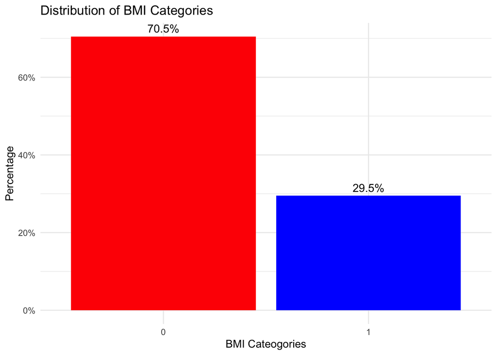

```r
summary_data <- full_dataset %>%
  count(hs_bmi_c_cat) %>%
  mutate(percentage = n / sum(n) * 100)

ggplot(data = summary_data, aes(x = as.factor(hs_bmi_c_cat), y = percentage)) +
  geom_bar(stat = "identity", fill = c("red", "blue")) +
  geom_text(aes(label = paste0(round(percentage, 1), "%")),
            vjust = -0.5, size = 4) +
  labs(title = "Distribution of BMI Categories",
       x = "BMI Cateogories",
       y = "Percentage") +
  scale_y_continuous(labels = scales::percent_format(scale = 1)) +
  theme_minimal() +
  theme(axis.text.x = element_text(angle = 0, hjust = 0.5))
```

After re-categorization, BMI category is moderately imbalanced. Given this moderate imbalance, we have decided to proceed with the model without making any adjustments.

## Correlation Matrix

Below is a correlation matrix to help decide which model is most appropriate for the data.This matrix is used to assess presence of multicollinearity.

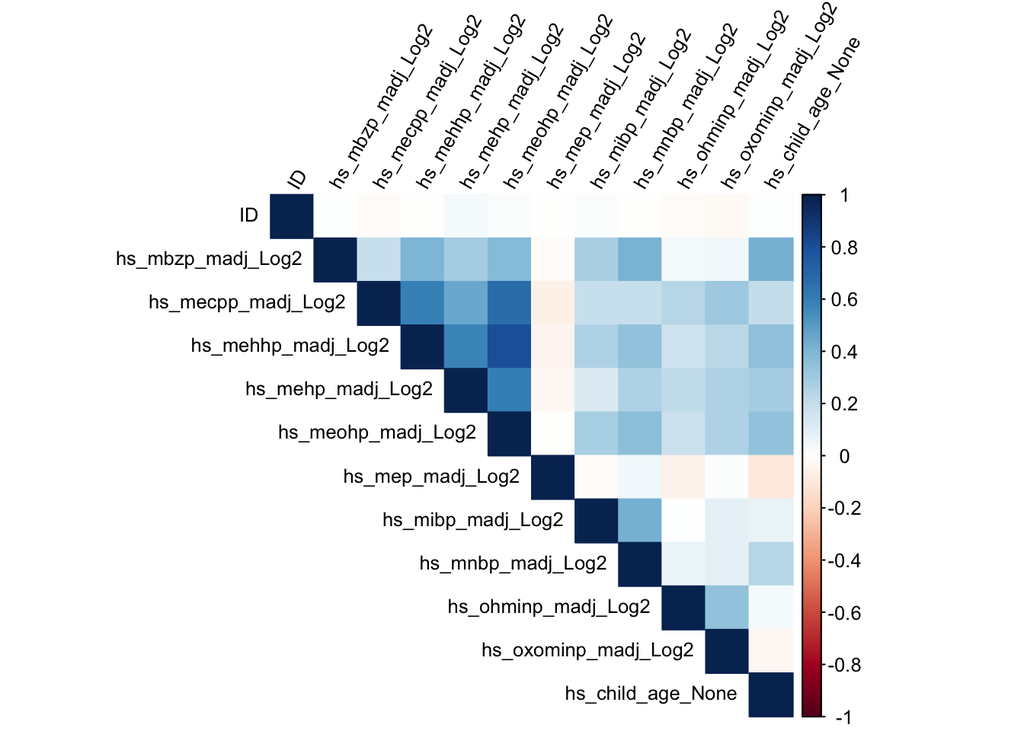

```r
numeric_vars <- exposome_phenotype_covariates %>%
  dplyr::select(where(is.numeric))

cor_matrix <- cor(numeric_vars, use = "complete.obs")
corrplot(cor_matrix, method = "color", type = "upper", tl.col = "black", tl.srt = 60, tl.cex = 0.8)
```

The correlation analysis revealed the following highly correlated pairs (70% threshold):

```r
find_highly_correlated <- function(cor_matrix, threshold = 0.8) {
  cor_matrix[lower.tri(cor_matrix, diag = TRUE)] <- NA
  cor_matrix <- as.data.frame(as.table(cor_matrix))
  cor_matrix <- na.omit(cor_matrix)
  cor_matrix <- cor_matrix[order(-abs(cor_matrix$Freq)), ]
  cor_matrix <- cor_matrix %>% filter(abs(Freq) > threshold)
  return(cor_matrix)
}
highly_correlated_pairs <- find_highly_correlated(cor_matrix, threshold = 0.70)
highly_correlated_pairs
```

| Var1 | Var2 | Freq |
| --- | --- | --- |
| hs_mehhp_madj_Log2 | hs_meohp_madj_Log2 | 0.8076375 |

Among these findings, `hs_mehhp_madj_Log2` was found to have a high correlation with `hs_meohp_madj_Log2`, with a correlation coefficient of 0.8076375. Given this high correlation, `hs_mehhp_madj_Log2` was removed from the model to address multicollinearity.

Despite considering group LASSO logistic regression to handle multicollinearity, regular LASSO regression was used for model building. To address the issue of multicollinearity, the variable `hs_mehhp_madj_Log2` was removed from the model.

```r
#Finalize the data set
outcome <- "hs_bmi_c_cat"
covariates_final <- c("h_cohort", "e3_sex_None") # Did not include age

diet_final <- c("e3_alcpreg_yn_None", "h_cereal_preg_Ter", "h_dairy_preg_Ter",
                "h_fastfood_preg_Ter", "h_folic_t1_None", "h_fruit_preg_Ter",
                "h_meat_preg_Ter", "h_pamod_t3_None", "h_fish_preg_Ter",
                "h_legume_preg_Ter", "h_pavig_t3_None", "h_veg_preg_Ter")
factorize_columns <- c(covariates_final, diet_final)
full_data_with_meta_imputed_factored <- full_data_with_meta_imputed %>%
  mutate(across(all_of(factorize_columns), as.factor))
```

# Model Building and Stastical Analysis

### Primary Models: Model Building (1A,1B,1C,1D)

LASSO Regression model will be used to compare the performance of different models predicting BMI categories. LASSO regression, known for its ability to perform both variable selection and regularization, is used here to determine the impact of varying predictor sets on model accuracy. The goal is to identify which combination of predictor variables yields the best model performance. AUC and important variables will be highlighted.

- *Model 1A*: Outcome ~ Covariates
- *Model 1B*: Outcomes ~ Covariates + Diet
- *Model 1C*: Outcomes ~ Covariates + Diet + Phthalates
- *Model 1D*: Outcomes ~ Covariates + Diet + Phthalates + Metabolomic Data

#### ROC Curves for Model 1:

In this section, ROC (Receiver Operating Characteristic) curves will evaluate the performance of four different models. ROC curves are used to assess the ability of a classification model to distinguish between different BMI categories.

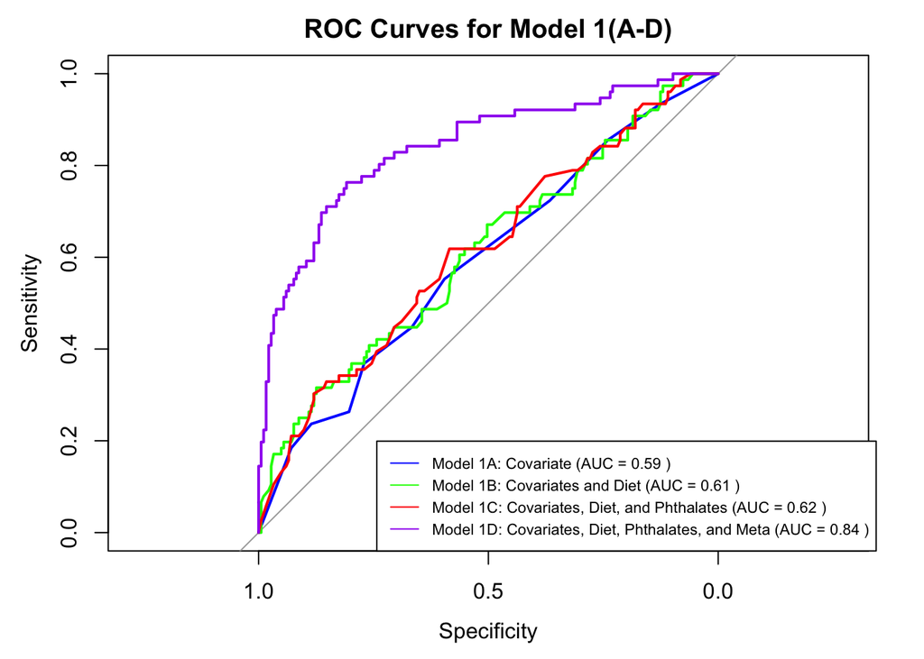

```r
outcome <- "hs_bmi_c_cat"
covariates_final <- c("h_cohort", "e3_sex_None", "hs_child_age_None")

phthalates_final <- c("hs_mbzp_madj_Log2", "hs_mecpp_madj_Log2", "hs_mep_madj_Log2",
                      "hs_mibp_madj_Log2", "hs_mnbp_madj_Log2", "hs_oxominp_madj_Log2",
                      "hs_meohp_madj_Log2", "hs_ohminp_madj_Log2",
                      "hs_mehp_madj_Log2") # removed the one variable hs_mehhp_madj_Log2

diet_final <- c("e3_alcpreg_yn_None", "h_cereal_preg_Ter", "h_dairy_preg_Ter",
                "h_fastfood_preg_Ter", "h_folic_t1_None", "h_fruit_preg_Ter",
                "h_meat_preg_Ter", "h_pamod_t3_None", "h_fish_preg_Ter",
                "h_legume_preg_Ter", "h_pavig_t3_None", "h_veg_preg_Ter")

meta_final <- grep("^metab_", names(full_data_with_meta_imputed_factored), value = TRUE)

# predictor sets
predictor_sets <- list(
  covariate = covariates_final,
  covariates_diet = c(covariates_final, diet_final),
  covariates_diet_phthalates = c(covariates_final, diet_final, phthalates_final),
  covariates_diet_phthalates_meta = c(covariates_final, diet_final, phthalates_final, meta_final)
)

# Function
model_performance <- function(predictors) {
  subset_data <- full_data_with_meta_imputed_factored[, c(predictors, outcome)]
  subset_data <- na.omit(subset_data)

  subset_data[[outcome]] <- as.factor(subset_data[[outcome]])

  # Hold out set
  set.seed(999)
  trainIndex <- createDataPartition(subset_data[[outcome]], p = .8, list = FALSE)
  train_data <- subset_data[trainIndex, ]
  test_data <- subset_data[-trainIndex, ]

  x_train <- model.matrix(as.formula(paste(outcome, "~ .")), data = train_data)[, -1]
  y_train <- train_data[[outcome]]
  x_test <- model.matrix(as.formula(paste(outcome, "~ .")), data = test_data)[, -1]
  y_test <- test_data[[outcome]]

  # Train
  covariates_train <- model.matrix(as.formula(paste(outcome, "~", paste(covariates_final, collapse = "+"))), data = train_data)[, -1]

  # Test
  covariates_test <- model.matrix(as.formula(paste(outcome, "~", paste(covariates_final, collapse = "+"))), data = test_data)[, -1]

  x_train <- cbind(covariates_train, x_train[, !colnames(x_train) %in% colnames(covariates_train)])
  x_test <- cbind(covariates_test, x_test[, !colnames(x_test) %in% colnames(covariates_test)])

  # Fit cv and alpha = 1 is LASSO
  cv_fit <- cv.glmnet(x_train, y_train, family = "binomial", alpha = 1)
  best_lambda <- cv_fit$lambda.min
  final_model <- glmnet(x_train, y_train, family = "binomial", alpha = 1, lambda = best_lambda)

  # Predict
  probabilities <- predict(final_model, s = best_lambda, newx = x_test, type = "response")

  roc_curve <- roc(y_test, as.numeric(probabilities))
  auc_value <- auc(roc_curve)
  coefficients <- coef(final_model, s = best_lambda)[-1, ]

  list(roc_curve = roc_curve, auc_value = auc_value, coefficients = coefficients)
}

# Look at all models
results <- lapply(predictor_sets, model_performance)

# ROC Curves
plot(results[[1]]$roc_curve, col = "blue", main = "ROC Curves for Model 1(A-D)", lwd = 2)
colors <- c("green", "red", "purple")
for (i in 2:length(results)) {
  lines(results[[i]]$roc_curve, col = colors[i-1], lwd = 2)
}


legend("bottomright", inset = c(-0.01, 0), legend = c(
  paste("Model 1A: Covariate (AUC =", round(results[[1]]$auc_value, 2), ")"),
  paste("Model 1B: Covariates and Diet (AUC =", round(results[[2]]$auc_value, 2), ")"),
  paste("Model 1C: Covariates, Diet, and Phthalates (AUC =", round(results[[3]]$auc_value, 2), ")"),
  paste("Model 1D: Covariates, Diet, Phthalates, and Meta (AUC =", round(results[[4]]$auc_value, 2), ")")
), col = c("blue", "green", "red", "purple"), lwd = 1, cex = 0.7, xpd = TRUE)
```

The evaluation of model performance using ROC curves and AUC values showed a significant differences in predictive accuracy across the models. Model 1A, which only included covariates, had an AUC of 0.59, indicating limited discriminatory power. Adding dietary variables in Model 1B improved the AUC slightly to 0.61. Model 1C, which included both dietary variables and phthalates, showed a slight increase in AUC to 0.62. However, the most substantial improvement was observed in Model 1D, which added metabolomic data in addition to covariates, diet, and phthalates, achieved an AUC of 0.84. Adding metabolomic data significantly improved the predictive performance in distinguishing between the two BMI categories.

#### Variable Importance for Model 1:

Variable importance (Top 10) quantifies how much each predictor contributes to the performance of a predictive model. It helps identify which variables have the most significant impact on the model’s predictions. Here’s an overview of which variables are the most influential when building the model:

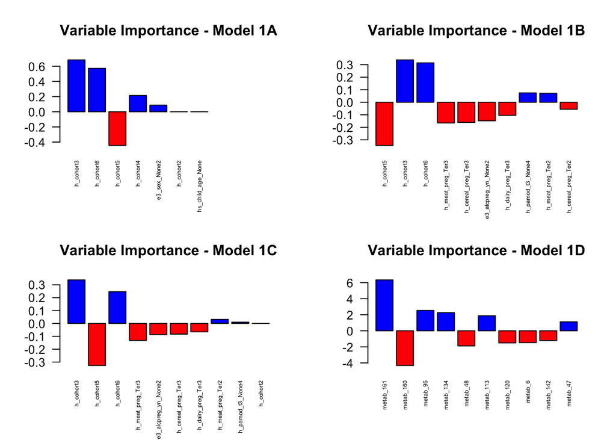

```r
par(mfrow = c(2, 2))
model_names <- c("Model 1A", "Model 1B", "Model 1C", "Model 1D")

for (i in 1:length(results)) {
  coeffs <- results[[i]]$coefficients
  top_coeffs <- coeffs[order(abs(coeffs), decreasing = TRUE)][1:10]
  colors <- ifelse(top_coeffs > 0, "blue", "red")
  barplot(top_coeffs, las = 2, main = paste("Variable Importance -", model_names[i]), cex.names = 0.48, col = colors)
}
```

Overall, the analysis reveals that while cohort and dietary factors are significant, the inclusion of metabolomic data provides a much stronger predictive power. This means that metabolomic factors are important for understanding how BMI is affected. Moving forward, incorporating metabolomic data and exploring other machine learning algorithms will be help refine the predictions and help with a deeper understanding of the effect of variables on BMI in children ages 6-11.

### Secondary Models: Advanced Machine Learning Modeling (2A,2B,2C)

In this section, the machine learning models will be refined to assess the best-performing model from Model 1. Based on the performance metrics, Model 1D, which includes metabolic data, showed the highest AUC result. LASSO, Random Forest, and GBM will be evaluated to see which model performs better when applied to the dataset from Model 1D. To minimize the risk of overfitting, hyperparamters were tuned using the 10-fold cross-validation (CV=10) approach.

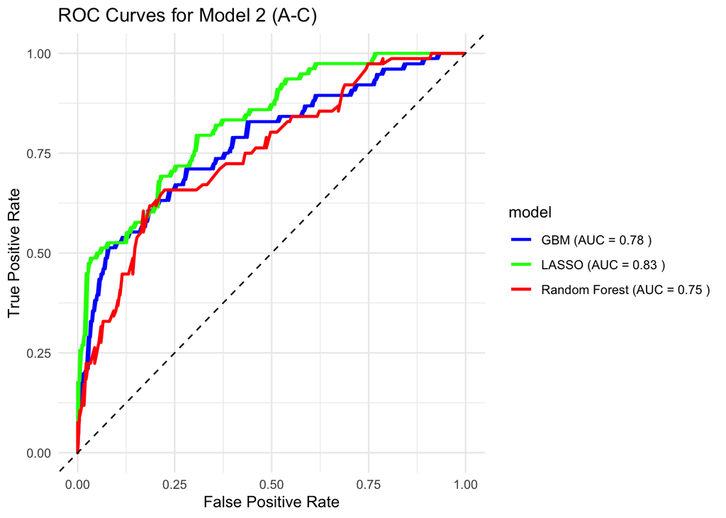

```r
data <- full_data_with_meta_imputed_factored
outcome <- "hs_bmi_c_cat"
covariates_final <- c("h_cohort", "e3_sex_None")
phthalates_final <- c("hs_mbzp_madj_Log2", "hs_mecpp_madj_Log2", "hs_mep_madj_Log2",
                      "hs_mibp_madj_Log2", "hs_mnbp_madj_Log2", "hs_oxominp_madj_Log2",
                       "hs_meohp_madj_Log2", "hs_ohminp_madj_Log2",
                      "hs_mehp_madj_Log2")
diet_final <- c("e3_alcpreg_yn_None", "h_cereal_preg_Ter", "h_dairy_preg_Ter",
                "h_fastfood_preg_Ter", "h_folic_t1_None", "h_fruit_preg_Ter",
                "h_meat_preg_Ter", "h_pamod_t3_None", "h_fish_preg_Ter",
                "h_legume_preg_Ter", "h_pavig_t3_None", "h_veg_preg_Ter")
meta_final <- grep("^metab_", names(data), value = TRUE)

all_vars <- c(covariates_final, phthalates_final, diet_final, meta_final)
X <- as.matrix(data[all_vars])
y <- data[[outcome]]  # outcome variable "hs_bmi_c_cat"

# Split training and testing sets
set.seed(999)
train_indices <- sample(1:nrow(X), size = 0.8 * nrow(X))
X_train <- X[train_indices, ]
X_test <- X[-train_indices, ]
y_train <- y[train_indices]
y_test <- y[-train_indices]

# Fit the LASSO model using cross-validation
cv_fit <- cv.glmnet(X_train, y_train, alpha = 1, family = "binomial")

# Best lambda value
best_lambda <- cv_fit$lambda.min
#print(paste("Best lambda:", best_lambda))

# Fit the final model on the entire training data
lasso_model <- glmnet(X_train, y_train, alpha = 1, lambda = best_lambda, family = "binomial")

# Predict on the test data
y_pred_prob_lasso <- predict(lasso_model, s = best_lambda, newx = X_test, type = "response")
y_pred_lasso <- ifelse(y_pred_prob_lasso > 0.5, 1, 0)

# Calculate ROC and AUC for LASSO
roc_obj_lasso <- roc(y_test, y_pred_prob_lasso)
auc_value_lasso <- auc(roc_obj_lasso)
#print(paste("LASSO AUC:", auc_value_lasso))

# LASSO accuracy
accuracy_lasso <- mean(y_pred_lasso == y_test)
#print(paste("LASSO Accuracy:", accuracy_lasso))

data$hs_bmi_c_cat <- as.factor(data$hs_bmi_c_cat)

# HO set
set.seed(999)
trainIndex <- createDataPartition(data$hs_bmi_c_cat, p = .8, list = FALSE, times = 1)
dataTrain <- data[trainIndex, ]
dataTest <- data[-trainIndex, ]

# training control
train_control <- trainControl(method = "cv", number = 10, search = "grid")

#  parameter grid for Random Forest
rf_tune_grid <- expand.grid(mtry = c(2, 4, 6, 8, 10))

# Train the Random Forest model with hp tuning
set.seed(999)
rf_model <- train(hs_bmi_c_cat ~ ., data = dataTrain, method = "rf", trControl = train_control, tuneGrid = rf_tune_grid)


#print(rf_model$bestTune)

# Predictions with Random Forest on the test set
rf_prob_predictions <- predict(rf_model, newdata = dataTest, type = "prob")[, 2]
rf_predictions <- predict(rf_model, newdata = dataTest)

# Evaluate the Random Forest model with confusion matrix
rf_conf_matrix <- confusionMatrix(rf_predictions, dataTest$hs_bmi_c_cat)
#print(rf_conf_matrix)

# ROC and AUC for Random Forest
rf_roc_curve <- roc(dataTest$hs_bmi_c_cat, rf_prob_predictions)
rf_auc_value <- auc(rf_roc_curve)
#print(paste("Random Forest AUC:", rf_auc_value))

# Random Forest accuracy
accuracy_rf <- rf_conf_matrix$overall['Accuracy']
#print(paste("Random Forest Accuracy:", accuracy_rf))

# GRID SEARCH
gbm_tune_grid <- expand.grid(interaction.depth = c(1, 3, 5), n.trees = c(50, 100, 150), shrinkage = c(0.01, 0.1), n.minobsinnode = 10)

# Train the GBM model with hyperparameter tuning
set.seed(999)
gbm_model <- train(hs_bmi_c_cat ~ ., data = dataTrain, method = "gbm", trControl = train_control, tuneGrid = gbm_tune_grid, verbose = FALSE)


#print(gbm_model$bestTune)

# Make predictions with GBM on the test set
gbm_prob_predictions <- predict(gbm_model, newdata = dataTest, type = "prob")[, 2]
gbm_predictions <- predict(gbm_model, newdata = dataTest)

# Evaluate the GBM model with confusion matrix
gbm_conf_matrix <- confusionMatrix(gbm_predictions, dataTest$hs_bmi_c_cat)
#print(gbm_conf_matrix)

# ROC and AUC for GBM
gbm_roc_curve <- roc(dataTest$hs_bmi_c_cat, gbm_prob_predictions)
gbm_auc_value <- auc(gbm_roc_curve)
#print(paste("GBM AUC:", gbm_auc_value))

# GBM accuracy
accuracy_gbm <- gbm_conf_matrix$overall['Accuracy']
#print(paste("GBM Accuracy:", accuracy_gbm))

# Combine ROC curves
roc_data_lasso <- data.frame(
  tpr = roc_obj_lasso$sensitivities,
  fpr = 1 - roc_obj_lasso$specificities,
  model = paste("LASSO (AUC =", round(auc_value_lasso, 2), ")")
)

roc_data_rf <- data.frame(
  tpr = rf_roc_curve$sensitivities,
  fpr = 1 - rf_roc_curve$specificities,
  model = paste("Random Forest (AUC =", round(rf_auc_value, 2), ")")
)

roc_data_gbm <- data.frame(
  tpr = gbm_roc_curve$sensitivities,
  fpr = 1 - gbm_roc_curve$specificities,
  model = paste("GBM (AUC =", round(gbm_auc_value, 2), ")")
)

roc_data_combined <- rbind(roc_data_lasso, roc_data_rf, roc_data_gbm)

# ROC curves together
ggplot(roc_data_combined, aes(x = fpr, y = tpr, color = model)) +
  geom_line(size = 1) +
  geom_abline(linetype = "dashed") +
  labs(title = "ROC Curves for Model 2 (A-C)", x = "False Positive Rate", y = "True Positive Rate") +
  theme_minimal() +
  scale_color_manual(values = c("blue", "green", "red"))
```

```r
#cat("LASSO Accuracy:", accuracy_lasso, "\n")
#cat("Random Forest Accuracy:", accuracy_rf, "\n")
#cat("GBM Accuracy:", accuracy_gbm, "\n")
```

##### Summary of Model Training and Evaluation for Secondary Model

#### Data Preparation:

1. **Dataset**: The dataset used includes covariates, phthalates, dietary variables, and metabolomic data.
2. **Outcome Variable**: The target variable for prediction is `hs_bmi_c_cat`.

#### Model Performance Summary

#### A. LASSO Regression

- **Best Lambda**: 0.00390940491989417
- **Performance**:
  - AUC: 0.8258
  - Accuracy: 80.46%
- **Variable Importance**: Located in Model 1D
- **Possible Reason for Best Performance**: The LASSO model likely performed the best due to its shrinkage feature, which penalizes less important variables. This is particularly beneficial given the influence of the metabolomic data in the dataset, allowing LASSO to focus on the most predictive features.

#### B. Random Forest

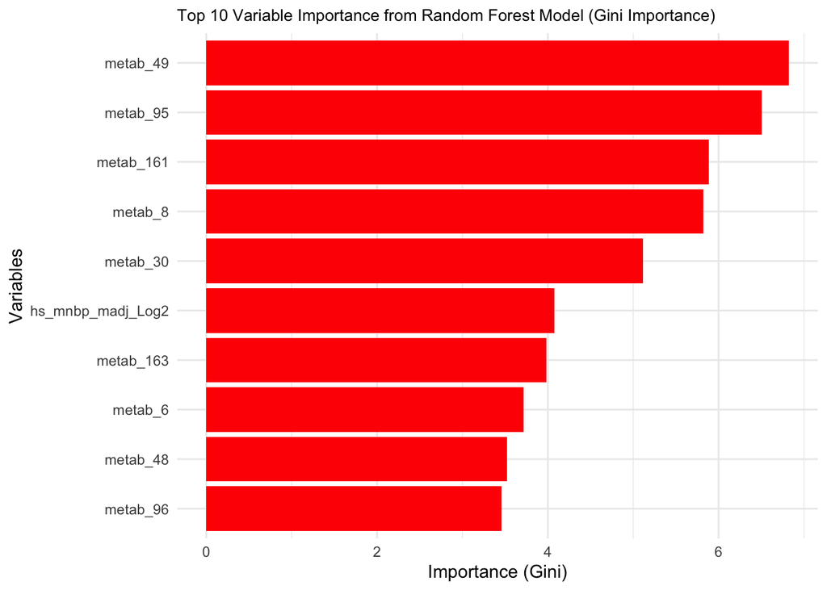

```r
var_importance <- varImp(rf_model, scale = FALSE)
var_importance_df <- as.data.frame(var_importance$importance)
var_importance_df$Variable <- rownames(var_importance_df)
var_importance_df <- var_importance_df[order(-var_importance_df$Overall), ]
top_10_vars <- head(var_importance_df, 10)

ggplot(top_10_vars, aes(x = reorder(Variable, Overall), y = Overall)) +
  geom_bar(stat = "identity", fill = "red") +
  coord_flip() +
  labs(title = "Top 10 Variable Importance from Random Forest Model (Gini Importance)",
       x = "Variables",
       y = "Importance (Gini)") +
  theme_minimal()+theme(plot.title = element_text(size = 10))
```

This bar plot above displays the top 10 variables by importance in the Random Forest model, measured by Gini Importance. The most important variables are `metab_49`, `metab_95`, `metab_161`, and `metab_8`. Other key variables include `metab_30`, `hs_mnbp_madj_Log2`, `metab_163`, `metab_6`,`metab_48`, and `metab_96`. These variables significantly contribute to the model’s predictive power, with `metab_49` having the highest impact.

#### C. Gradient Boosting Machine (GBM)

- **Parameter Tuning**: The model was tuned using a grid search with the following best parameters:
  - `n.trees`: 100
  - `interaction.depth`: 3
  - `shrinkage`: 0.1
  - `n.minobsinnode`: 10
- **Performance**:
  - AUC: 0.7757
  - Accuracy: 77.61%
- **Variable Importance**:

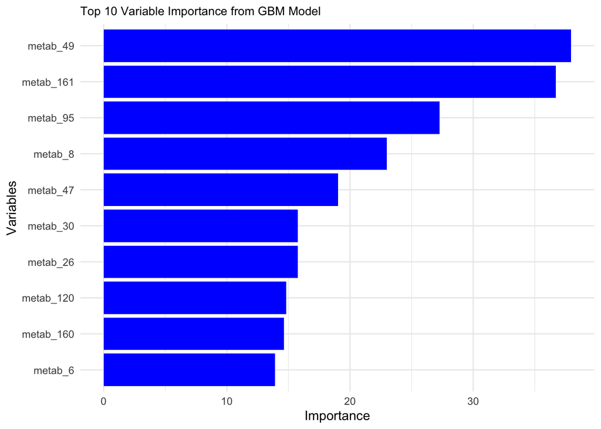

```r
var_importance_gbm <- varImp(gbm_model, scale = FALSE)
var_importance_gbm_df <- as.data.frame(var_importance_gbm$importance)
var_importance_gbm_df$Variable <- rownames(var_importance_gbm_df)
var_importance_gbm_df <- var_importance_gbm_df[order(-var_importance_gbm_df$Overall), ]


top_10_vars_gbm <- head(var_importance_gbm_df, 10)
ggplot(top_10_vars_gbm, aes(x = reorder(Variable, Overall), y = Overall)) +
  geom_bar(stat = "identity", fill = "blue") +
  coord_flip() +
  labs(title = "Top 10 Variable Importance from GBM Model",
       x = "Variables",
       y = "Importance") +
  theme_minimal() +
  theme(plot.title = element_text(size = 10))
```

This bar plot displays the top 10 variables by importance in the Gradient Boosting Machine (GBM) model. The most important variables are `metab_49`, `metab_161`, and `metab_95`. Other significant variables include `metab_8`, `metab_47`, `metab_30`, `metab_26`, `metab_120`, `metab_160`, and `metab_6`. These variables significantly contribute to the model’s predictive power.

#### ROC and AUC Analysis:

- The ROC curves and AUC values for all three models were plotted to compare their performance visually. The LASSO model showed the highest AUC (0.8258), followed by GBM (0.7757), and Random Forest (0.7508).

#### Comparing Model Accuracy 2 (A-C)

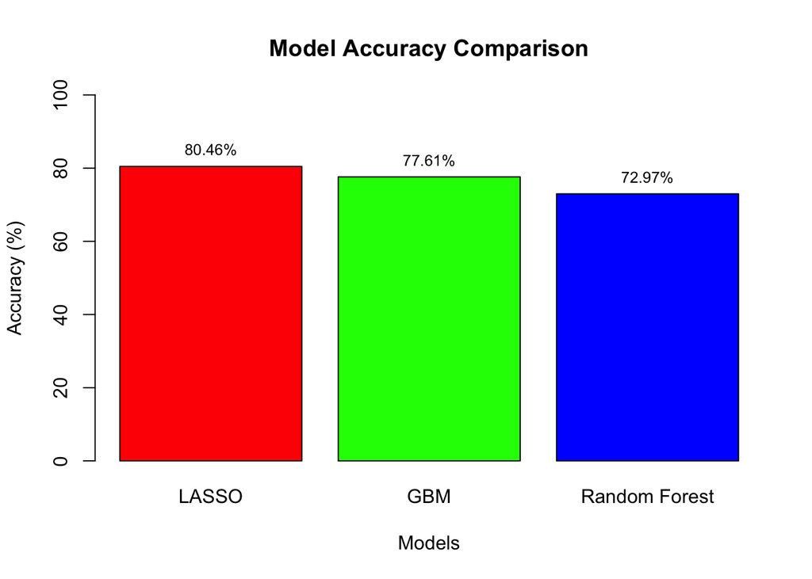

```r
models <- c("LASSO", "Random Forest", "GBM")
accuracy <- c(0.8045977, 0.7297297, 0.7760618)

data <- data.frame(models, accuracy)
data <- data[order(-data$accuracy),]
data$accuracy <- data$accuracy * 100

colors <- c("red", "green", "blue")

barplot(data$accuracy,
        names.arg = data$models,
        col = colors,
        ylim = c(0, 100),
        main = "Model Accuracy Comparison",
        xlab = "Models",
        ylab = "Accuracy (%)")

text(x = barplot(data$accuracy, plot = FALSE),
     y = data$accuracy,
     label = paste0(round(data$accuracy, 2), "%"),
     pos = 3,
     cex = 0.8,
     col = "black")
```

This bar plot above compares the accuracy of three machine learning models: LASSO, GBM, and Random Forest on Model 1D. The LASSO model achieved the highest accuracy at 80.46%, followed by the GBM model at 77.61%, and the Random Forest model at 72.97%. This visualization highlights LASSO as the most accurate model among the three.

# Conclusion

In Model 2, LASSO, Random Forest, and GBM algorithms were evaluated on Model 1D. LASSO achieved the highest accuracy and AUC, demonstrating the best predictive performance. This is likely due to LASSO’s shrinkage capability, which manages high-dimensional metabolomic data by focusing on relevant predictors.

Metabolomic data dominated variable importance in the LASSO (Model 1D), Random Forest, and GBM models. The strength of metabolomic data in these models may be attributed to the inherent biological relevance of these variables to BMI. Further analysis is needed to determine the optimal machine learning technique.

LASSO was chosen for this dataset for several reasons. Firstly, it achieved the highest performance in terms of both accuracy and AUC/ROC, indicating the best predictive capability. Additionally, LASSO’s shrinkage factor is well-suited for handling high-dimensional data. LASSO effectively reduces the coefficients of less important variables to zero, focusing the model on the most relevant predictors and thereby mitigating overfitting.

The focus is to ensure that all relevant variables are being considered in the model while maximizing predictive performance. Therefore, LASSO is preferred for this dataset due to its ability to handle large and complex datasets, combined with its strong performance metrics.

# Future Work and Limitations

*Assess Different Models*: While LASSO has shown the best performance, further evaluation of other machine learning models could provide additional information and improvements.

*Assess Multicollinearity Among Metabolite Data*: Investigating the multicollinearity among metabolite variables will help to understand their interrelationships and to make sure that the model’s assumptions are not violated.

*Model Diagnostics*: Perform residual analysis to check the assumptions of the regression model, such as linearity, independence, homoscedasticity, and normality of residuals.

*Hyperparameter Tuning*: Optimize the LASSO regularization parameter (lambda) through cross-validation (ex. LOOCV) to ensure the model is neither over-penalizing nor under-penalizing the predictors.

By undertaking these additional consideration, informed decision-making can contribute to better predictive performance.

# Reference

- https://cran.r-project.org/web/packages/grplasso/grplasso.pdf
- [Valvi et al., 2020](https://www.ncbi.nlm.nih.gov/pmc/articles/PMC8157593/)
- [Luo et al., 2020](https://www.ncbi.nlm.nih.gov/pmc/articles/PMC7559247/)
- [NCBI, 2024](https://www.ncbi.nlm.nih.gov/pmc/articles/PMC9824240/)
- [Serrano et al., 2021](https://www.ncbi.nlm.nih.gov/pmc/articles/PMC7483495/)